# An analysis of data on educational attainment and deprivation in Scotland

Muyuan Yao

03/05/2022

## Introduction

The aim of our study is to find out and understand the relationship between distinct variables including employment rate, alcohol, attendance, broadband, and the educational attainment. The data include various variables for different “data zones” in Scotland. The data used in this report are `scottishData.csv` containing a sample of the “Indicator” data that were used to compute the 2020 Scottish Index of Multiple Deprivation (SIMD), a tool used by government bodies to support policy-making. Data zones are small geographical areas typically containing a population of between 500 and 1000 people. There are 6,976 data zones in total in Scotland, but the analysis in this report focuses on a sample of 400 of them, of which 100 are from the Glasgow City, 100 are from City of Edinburgh, and 200 are from elsewhere in Scotland. The data set contains many different variables, of which we will focus in particular on attendance and crime rate. Once we find the relationship, it is easier to help the government make better policy and decision to improve the educational attainment.

## Methods

We use various methods of exploratory data analysis, including graphic analysis to test method, and performing hypothesis tests to determine the relation between two variables by selecting different hypothesis. We use exploratory plots to visualize the trend and characteristic of a group of data. Specifically, we use histograms, boxplot, and Q-Q plots to show the data. Then, a matrix fo scatter-plots is used to find out the connection between them. Finally, a hypothesis is operated to seek for a regression between the attainment and variables.

## Results

### Comparing educational attainment between the cities of Glasgow and Edinburgh

In this section, we focus on the available data for Glasgow and Edinburgh, for each of which the data set contains 100 observations (data zones). For these data zones, the following boxplots summarise the distribution of the educational attainment variable:

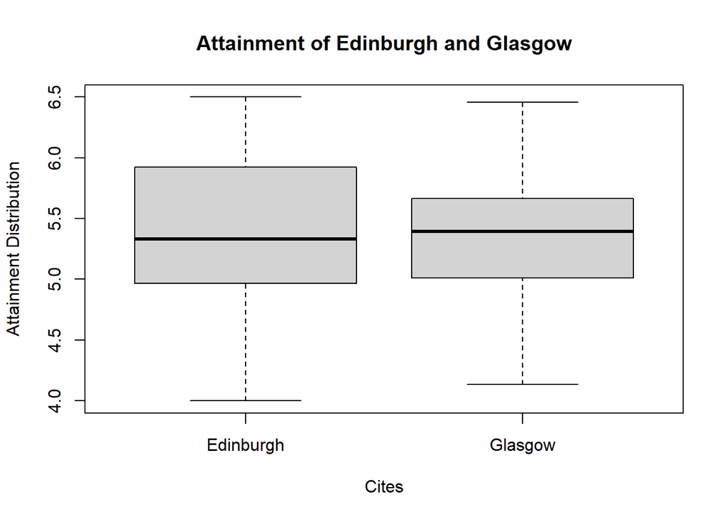

Figure 1: Boxplot for attainment of Edinburgh and Glasgow.

Table 1: Summary statistics of attainment of Edinburgh and Glasgow.

|  | Edinburgh | Glasgow |
| --- | --- | --- |
| Mean | 5.394 | 5.367 |
| Variance | 0.377 | 0.204 |

As further numerical summaries of overall attainment and variability in attainment, we compute the sample means and variances respectively. The sample mean attainments for Glasgow and Edinburgh are $\bar{x}_G = 5.367$ and $\bar{x}_E = 5.394$, and the sample variances are $s^2_G = 0.204$ and $s^2_E = 0.377$.

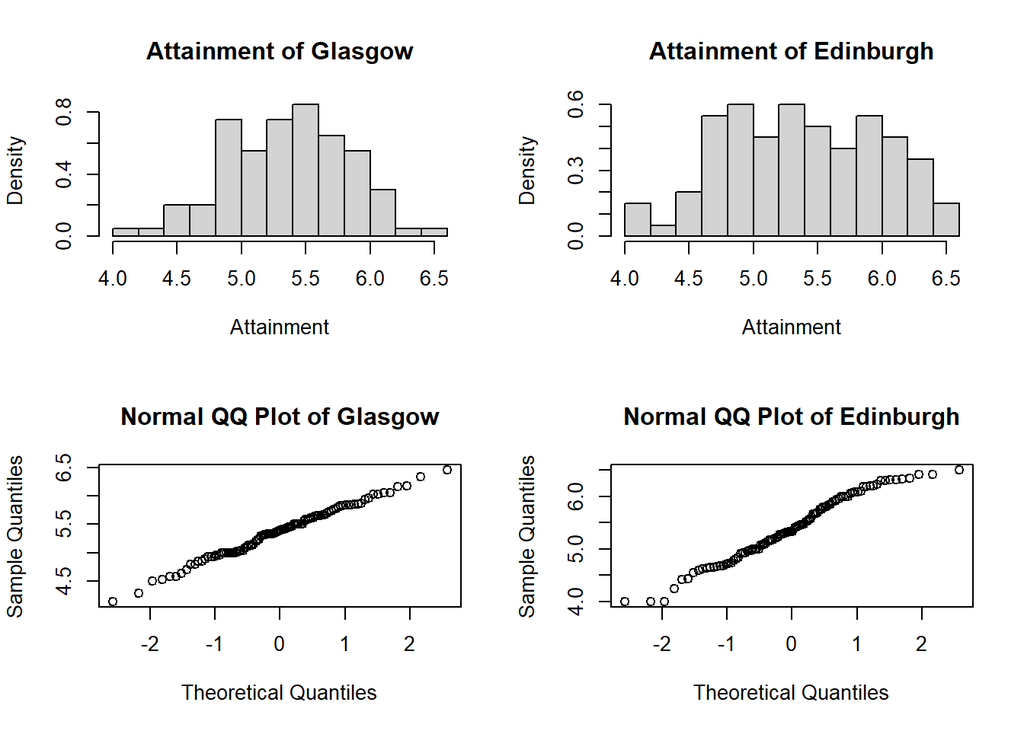

Figure 2: A histogram of the Attainment variable for each of Glasgow and Edinburgh

To investigate whether or not the variance of attainment is the same in Glasgow and Edinburgh, we consider the null and alternative hypotheses $H_0: \sigma^2_G = \sigma^2_E$ vs $H_0: \sigma^2_G \neq \sigma^2_E$ and can use a test based on the statistic $F=\frac{S^2_{G}/σ^2_{G}}{S^2_{E}/σ^2_{E}}∼F_{nX−1,nY−1}$ . If $H_0$ is true, and supposing the data are normally distributed (as the sample space is large enough), then $F=\frac{S^2_{G}}{S^2_{E}}$ has a $F$ distribution. The value of this $F$ statistic that we compute from the data is 0.54036. The lower and upper quantiles of the null distribution are 0.67284 and 1.48623 at 95% confidence level, and since the statistic $F<0.67284$ therefore we reject $H_0$, which is an evidence that they have different variance.

### Investigating the relationship between educational attainment and other variables

In this section we consider together all of the observations in the data set, not distinguishing whether the observations were from Glasgow, Edinburgh or elsewhere in Scotland.

The following Figure 3 shows the relationship between the various variables described in the Introduction section above.

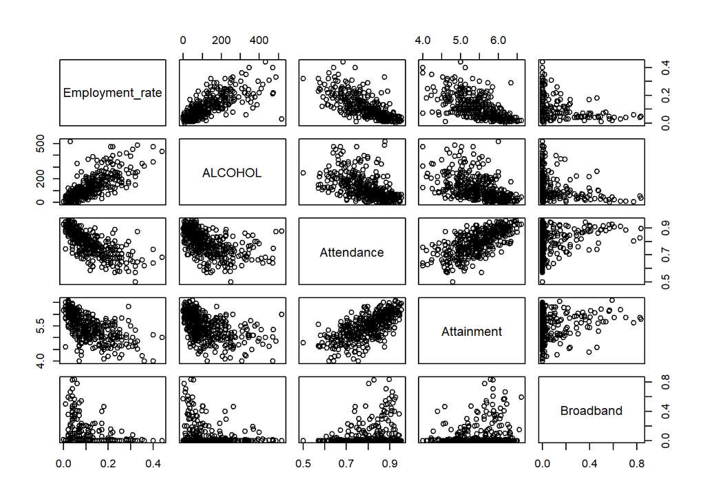

Figure 3: pairwise scatterplots for the 5 variables

Table 2: Correlation pairwise.

|  | Employment_rate | ALCOHOL | Attendance | Attainment | Broadband |
| --- | --- | --- | --- | --- | --- |
| Employment_rate | 1.0000000 | 0.7549826 | -0.7283002 | -0.6177307 | -0.2124862 |
| ALCOHOL | 0.7549826 | 1.0000000 | -0.5400995 | -0.4936659 | -0.1874733 |
| Attendance | -0.7283002 | -0.5400995 | 1.0000000 | 0.6912380 | 0.2458537 |
| Attainment | -0.6177307 | -0.4936659 | 0.6912380 | 1.0000000 | 0.1593356 |
| Broadband | -0.2124862 | -0.1874733 | 0.2458537 | 0.1593356 | 1.0000000 |

The corresponding numerical values for the Pearson sample correlation coefficients between these variables are showed in the above table.

According to the plots, we can find that there is positive linear relation between Attendance and Attainment, Employment_rate and ALCOHOL since they both have large correlation. This means they have a positive linear relation. Additionally, Attendence and Employment_rate have a negative linear relation with -0.72830. In the meantime, Broadband has weak linear relation with other four variables.

We plot again as follows the attainment rate versus the attendance, with an added line of best fit for a regression model.

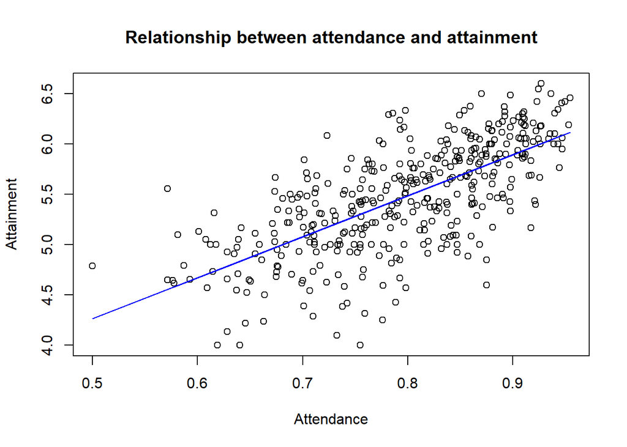

Figure 4: The Relationship between attendance and attainment

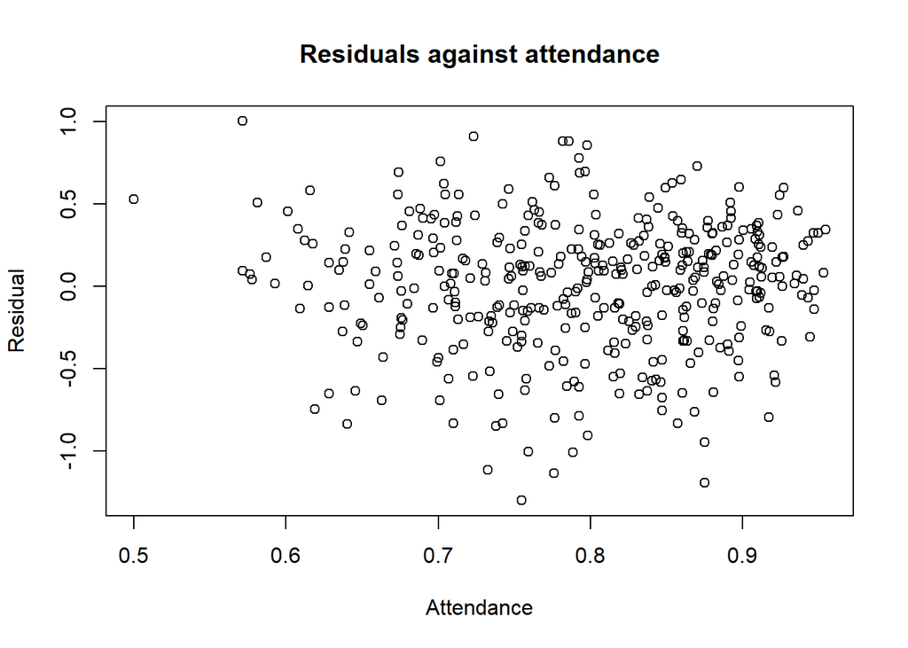

Figure 5: Residuals against attendance

The line of best fit is of the form attainment = $\beta_0$ + $\beta_1 \times$ attendance where the least-squares estimates of $\beta_0$ and $\beta_1$ are 2.2232 and 4.0788, respectively. The value of the statistic $t = { \hat{\beta}_1}/\left( \hat{\sigma} / \sqrt{ (n-1)s_x^2 }\right)$, which is useful for testing $H_0: \beta_1 = 0$ vs $H_1: \beta_1 \neq 0$ and has a *t* distribution under $H_0$, equals 19.08. This corresponds to a $p$-value of $2e^{-16}$ confirming there is a strong evidence against $H_0$, which means the slope does not equal to 0, and the linear relation holds.

### Investigating the relationship between educational attainment and crime

In this section, we investigate relationship between educational attainment and crime. The factor crime is made up with crime count and crime rate. The scatter plot of crime are showed below.

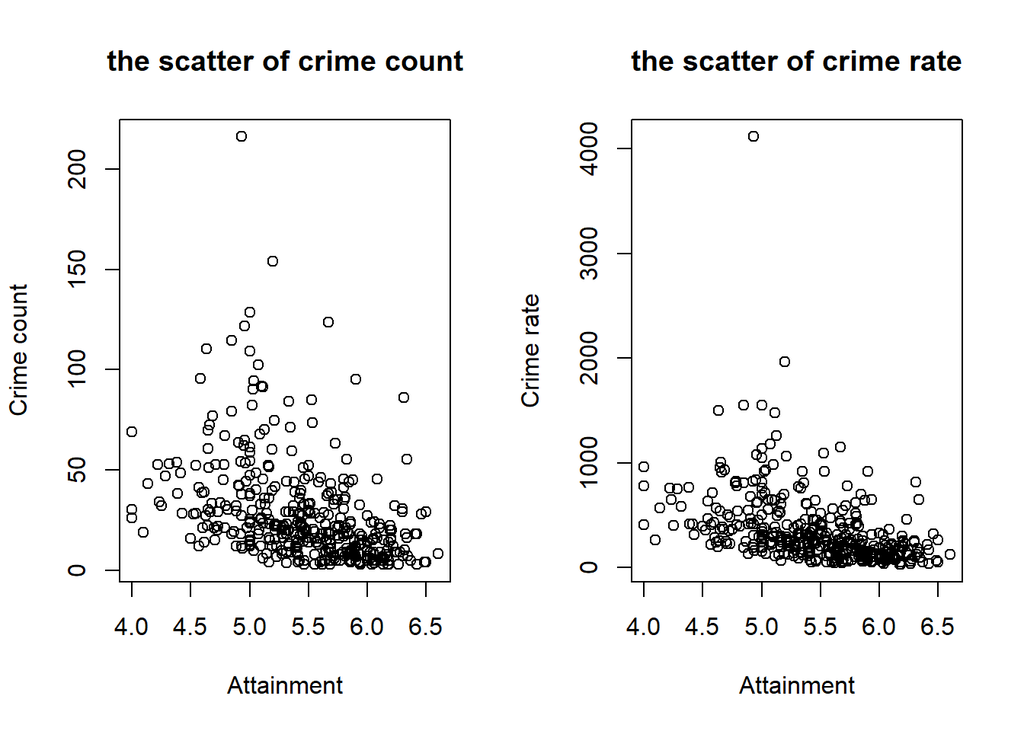

Figure 6: Scatter plot of crime and attainment

From the figure above, we can find out that the crime count and attainment may have a negative linear relation. Thus, we apply a linear regression to figure out the relation between them. We plot as follows the attainment rate versus the crime count, with an added line of best fit for a regression model.

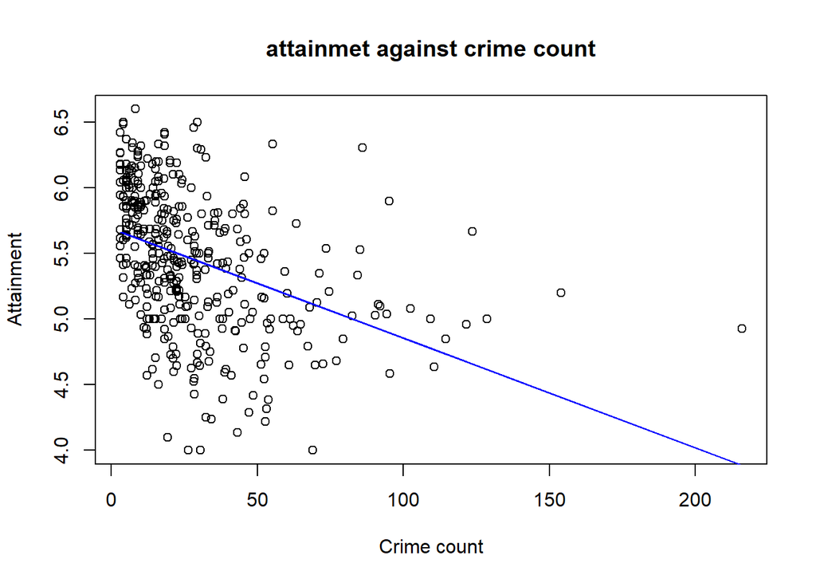

Figure 7: Relationship between crime count and attainment

## Conclusions

We have investigated various characteristics of data available for geographical areas in Scotland called “data zones”, focusing in several particular variables which may have relationship with the educational attainment via the data obtained from the Glasgow City and City of Edinburgh.

We found that Edinburgh has a larger range of educational attainment, while Glasgow has a slightly higher median and they have the different variance of attainment. It is found out that the variable ‘Attendance’ has a positive linear relation with attainment; the variable ‘crime count’ has a negative linear relation with attainment.

There are some limitations of the current study. One is that there some ‘bad point’ in the data, for example, we have zeros in the data zones. A future study could investigate in what degree do the different variables influence each other, and find out the leading variable that attaches the attainment.

## Appendix

The R code to produce the analysis and plots in this report is as follows:

```r
knitr::opts_chunk$set(echo = TRUE)
dat <- read.csv("scottishData.csv")


Edinburgh <- subset(dat, Council_area == "City of Edinburgh")
Glasgow <- subset(dat, Council_area == "Glasgow City")
boxplot(Edinburgh$Attainment, Glasgow$Attainment, names = c("Edinburgh","Glasgow"),
        xlab = "Cites", ylab = "Attainment Distribution", main = "Attainment of Edinburgh and Glasgow")

means <- round(c(mean(Edinburgh$Attainment), mean(Glasgow$Attainment)),3)
variance <- round(c(var(Edinburgh$Attainment), var(Glasgow$Attainment)),3)
summary_stats <- rbind(means, variance)
colnames(summary_stats) <- c("Edinburgh","Glasgow")
rownames(summary_stats) <- c("Mean", "Variance")
knitr::kable(summary_stats, caption = "Summary statistics of attainment of Edinburgh and Glasgow.", align='c')

Edinburgh<-subset(dat, Council_area == "City of Edinburgh")
Glasgow<-subset(dat, Council_area == "Glasgow City")
par(mfrow=c(2,2))

hist(Glasgow$Attainment,freq=FALSE,xlab = "Attainment", ylab = "Density", breaks = 15, main = "Attainment of Glasgow")
hist(Edinburgh$Attainment, freq=FALSE,xlab = "Attainment", ylab = "Density", breaks = 15, main = "Attainment of Edinburgh")
qqnorm(Glasgow$Attainment, main = "Normal QQ Plot of Glasgow")
qqnorm(Edinburgh$Attainment, main = "Normal QQ Plot of Edinburgh")
pairs(dat[,c(8,11,17,18,31)])
k<-cor(dat[,c(8,11,17,18,31)])
knitr::kable(k, caption = "Correlation pairwise.",align='c')

relationship <- lm(dat$Attainment~dat$Attendance)
plot(dat$Attendance, dat$Attainment, xlab = "Attendance", ylab ="Attainment",main = "Relationship between attendance and attainment")
lines(dat$Attendance, 4.0788*dat$Attendance+2.2232,col='blue')
plot(dat$Attendance,relationship$residuals,main="Residuals against attendance",xlab = "Attendance",ylab = "Residual")
par(mfrow = c(1,2))
plot(dat$Attainment,dat$crime_count,xlab="Attainment",ylab="Crime count",main="the scatter of crime count")
plot(dat$Attainment,dat$crime_rate,xlab="Attainment",ylab="Crime rate",main="the scatter of crime rate")
relationship <- lm(dat$Attainment~dat$crime_count)
plot(dat$crime_count, dat$Attainment, xlab = "Crime count", ylab ="Attainment", main='attainmet against crime count')
lines(dat$crime_count, -0.0083443*dat$crime_count+5.6893926,col = 'blue')
```